# Data Skills 03 - Introduction to ggplot2 for Plotting

Christopher Prener, Ph.D.

(October 24, 2022)

## Dependencies

This notebook requires two packages from the `tidyverse` as well as two additional packages:

```r
# tidyverse packages
library(dplyr)     # data wrangling
library(ggplot2)   # read and write csv files

# manage file paths
library(here)      # manage file paths
```

## Load Data

For today’s session, we’ll use the `penguins` data in the `palmerpenguins` package.

```r
penguins <- palmerpenguins::penguins
```

Notice how we can load a data set or function without including it in our code chunk above where packages are loaded. Instead we use the `package::object` or `package::function` syntax. This can be useful when multiple packages have functions with the same name, when writing our own functions, and when we need only a single instance of a function or data object in an analysis.

## Introduction to Grammar of Graphics

The first step in thinking creatively about data visualization is to appreciate that graphics are built upon an underlying grammar. There are two key things to note about the grammar of graphics:

- Meaningful plots are built around matching the right data with the right method of visualization.
- Graphics are made up of distinct layers of grammatical elements.

The data we have are matched to the selected method of visualization using **aesthetic mappings**. After we have defined our data source and the appropriate mappings, we visualize the data with some combination of **geometric objects** (or **geoms**) or statistical transformations. **Scales** for each aesthetic mapping are used to define how they appear (both in terms of numeric values and color), and plots can be customized using a combination of **labels** and **themes**.

## Introduction to `ggplot2`

Hadley Wickham’s `ggplot2` package implements this grammar of graphics in `R`. We’ll use the `penguins` data we loaded above today, but it is important to note that most (if not all) actual data visualization projects require some level of data cleaning ahead of time to make sure the data are measured correctly and are in the right format (long vs. wide).

Here is a very basic plot that we will iterate on below. Note that the primary function here is `ggplot()` and that functions are chained together with the `+` sign instead of `%>%`. Both of these are common stumbling blocks when folks are starting out with `ggplot2`.

In our `ggplot()` function, we define the default data source (`penguins`) and our **aesthetic mappings**. Once those have been defined, we add `geom_point()` to make a scatter plot based on these aesthetic mappings.

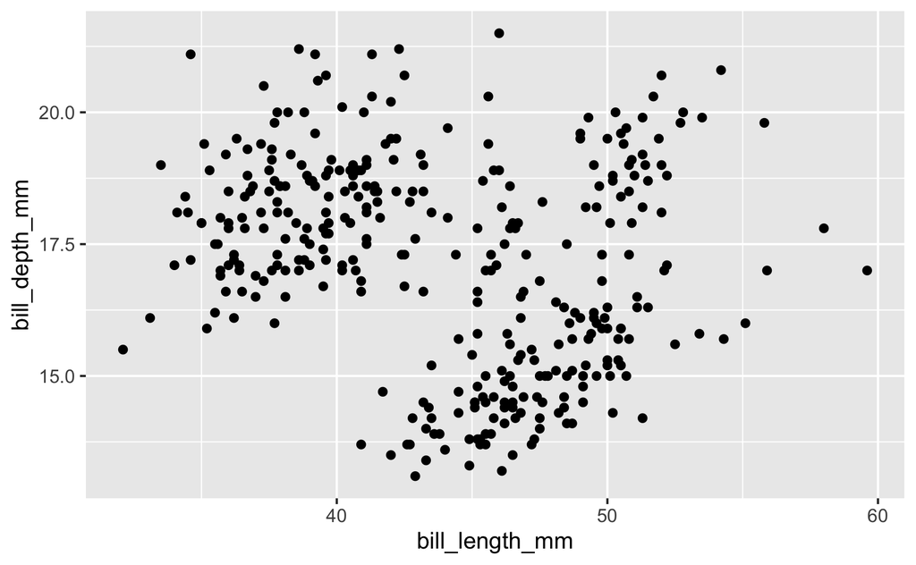

```r
ggplot(data = penguins, mapping = aes(x = bill_length_mm, y = bill_depth_mm)) +
  geom_point()
```

```r
penguins <- filter(penguins, is.na(bill_length_mm) == FALSE)
```